# Building a NAS using a Laptop (Based on Ubuntu)

## Introduction

- A `Network Attached Storage (NAS)` is a dedicated file storage system that provides `local area network (LAN)` users with centralized, consolidated disk storage through a standard Ethernet connection.
- In this tutorial, we will guide you through the steps to turn your old laptop into a NAS using Ubuntu.

## Prerequisites

- An old laptop with Ubuntu installed.
- An external hard drive or SSD for additional storage.
- A stable network connection.
- Basic knowledge of Linux commands.

## Step 1: Update and Upgrade Your System

- First, ensure your system is up to date. Open a terminal and run the following commands:

  ```
  sudo apt update
  sudo apt upgrade
  ```

## Step 2: Set Up a Static IP Address

- To ensure your `NAS` has a consistent IP address, you need to set up a `static IP`. Open a terminal and edit the network configuration file:
- **Why?** We want your `NAS` to have a permanent IP (say, `192.168.1.100`) so you always know where to find it.

  ```
  sudo nano /etc/netplan/01-netcfg.yaml
  ```

- Add the following configuration, replacing the values with your network details (This is just a example, replace `address` and `Gateway` with yours):

  ```
  network:
    version: 2
    renderer: networkd
    ethernets:
      eth0:
        dhcp4: no
        addresses:
          - 192.168.1.100/24
        gateway4: 192.168.1.1
        nameservers:
          addresses: [8.8.8.8, 8.8.4.4]
  ```

- Apply the changes:

  ```
  sudo netplan apply
  ```

### Alternative: Set Up Static IP Address Using GUI

- If you prefer to use a graphical user interface (GUI) to set up a static IP address, follow these steps:
  1. Click on the network icon in the system tray.
  2. Select the WiFi network you are connected to and click on "`Settings`".
  3. Go to the "`IPv4`" tab.
  4. Change the "Method" to "Manual".
  5. Enter your desired `IP address`, `Netmask`, and `Gateway`.
  6. Add `DNS servers` if needed.
  7. Save the settings and reconnect to the network.

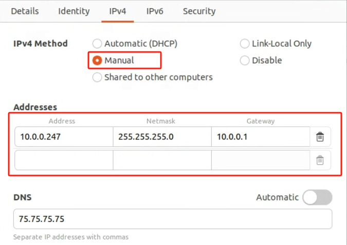

## Step 3: Install OpenSSH Server and Test It

- To remotely access your NAS, you need to install the OpenSSH server. Open a terminal and run the following command:

  ```
  sudo apt install openssh-server
  ```

- Once installed, start and enable the SSH service:

  ```
  sudo systemctl start ssh
  sudo systemctl enable ssh
  ```

- Test the SSH status on your laptop

  ```
  sudo systemctl status ssh
  ```

- Test the SSH connection from another machine on the same network:

  ```
  ssh username@192.168.1.100
  ```

- Replace `username` with your actual username and `192.168.1.100` with the static IP address you set up.

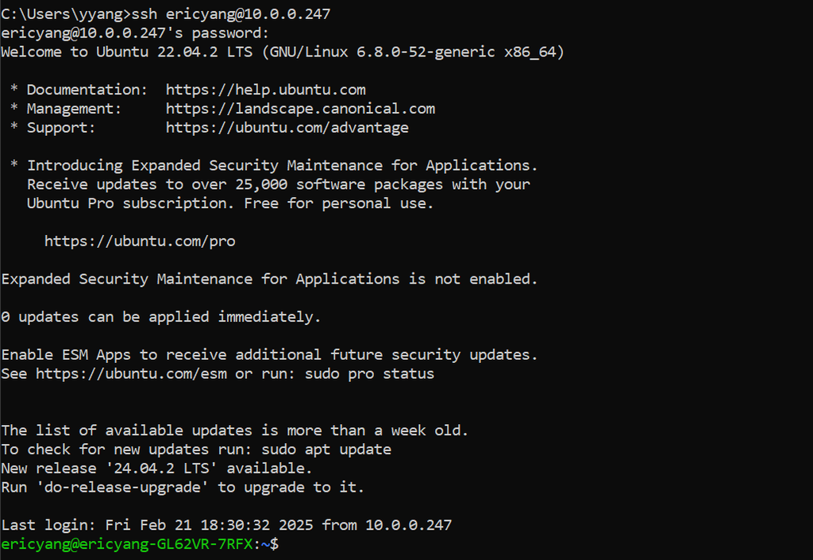

## Additional Step: Set Up Remote Access with GUI Using Chrome Remote Desktop

- To access your NAS with a graphical user interface (GUI), you can use Chrome Remote Desktop. Follow these steps:

### Install Chrome Remote Desktop

- Open a terminal and run the following commands to install Chrome Remote Desktop:

  ```
  wget https://dl.google.com/linux/direct/chrome-remote-desktop_current_amd64.deb
  sudo dpkg -i chrome-remote-desktop_current_amd64.deb
  sudo apt-get install -f
  ```

### Install Google Chrome

- If you don't have Google Chrome installed, download and install it:

  ```
  wget https://dl.google.com/linux/direct/google-chrome-stable_current_amd64.deb
  sudo dpkg -i google-chrome-stable_current_amd64.deb
  sudo apt-get install -f
  ```

### Install Desktop Environment

- Install a desktop environment if you don't have one. For example, you can install Xfce:

  ```
  sudo apt install xfce4 xfce4-goodies
  ```

### Configure Chrome Remote Desktop

- Link your Google account to Chrome Remote Desktop by visiting remotedesktop.google.com and following the instructions.
- Set up a new remote access session and choose a name and PIN for your NAS.

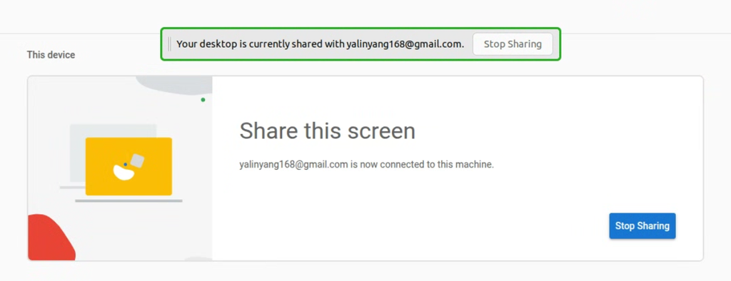

## Step 4: Mount All Drives Permanently and Set Up Easy-to-Remember Mount Paths

### Identify Your Drives

- First, identify the drives you want to mount. Open a terminal and run:

  ```
  sudo fdisk -l
  ```

- For GUI, go to `disk` to check your disk info

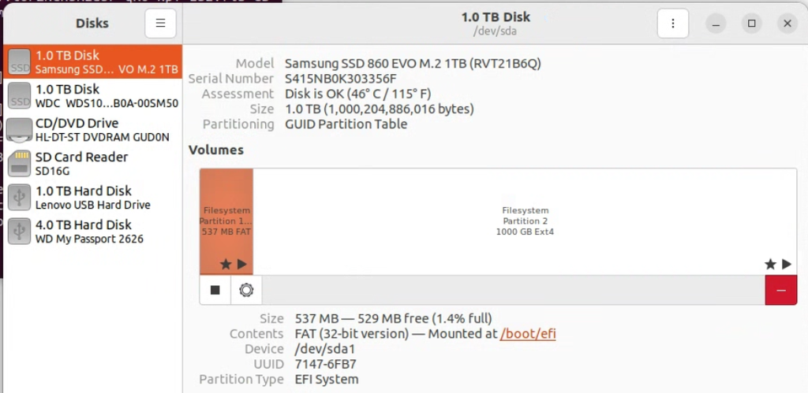

### Create Mount Points

- Create directories where you want to mount your drives. For example:

  ```
  sudo mkdir -p /mnt/storage1
  sudo mkdir -p /mnt/storage2
  ```

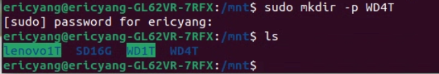

### Edit the mount options in `disk` (GUI)

- Uncheck Default option, check `Mount at system startup`
- Change the `Mount Point` to where you just setup

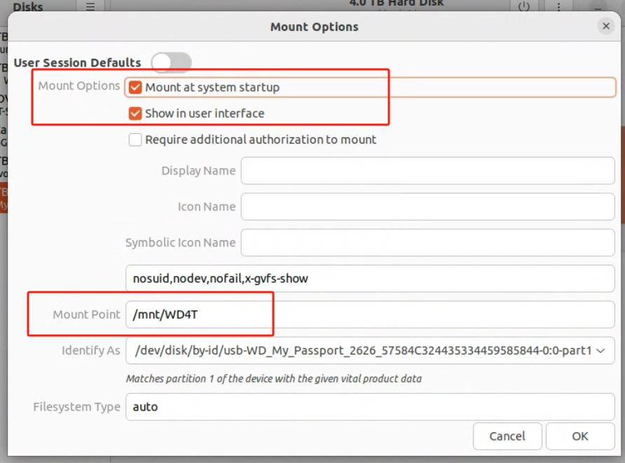

### Edit the mount option using `cmd`

- To mount the drives permanently, edit the `/etc/fstab` file:

  ```
  sudo nano /etc/fstab
  ```

- Add entries for your drives. Replace `UUID` with the actual UUID of your drives, which you can find using the `blkid` command:

  ```
  UUID=your-drive-uuid-1 /mnt/storage1 ext4 defaults 0 0
  UUID=your-drive-uuid-2 /mnt/storage2 ext4 defaults 0 0
  ```

- Mount the Drives
  - Apply the changes and mount the drives:

    ```
    sudo mount -a
    ```

- Verify the Mounts
  - Verify that the drives are mounted correctly:

    ```
    df -h
    ```

Now your drives are mounted permanently with easy-to-remember names.

## Step 5: Share Drives Using SMB

### Install Samba

- To share your drives over the network, you need to install Samba. Open a terminal and run the following command:

  ```
  sudo apt install samba
  ```

### Configure Samba

- Edit the Samba configuration file to add your shared drives:

  ```
  sudo nano /etc/samba/smb.conf
  ```

- Add the following configuration at the **end of the file**, replacing the `paths` with your actual mount points:

  ```
  [share]
  comment = share folder
  browseable = yes
  path = /home/book/Share
  create mask = 0755
  directory mask = 0755
  valid users = book
  force user = book
  force group = book
  public = yes
  available = yes
  writable = yes
  ```

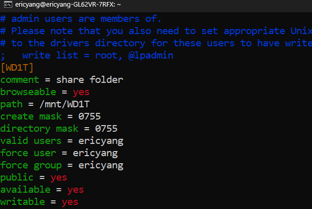

### Create Samba User

- Create a Samba user and set a password:

  ```
  sudo smbpasswd -a your_username
  ```

### Restart Samba Service

- Restart the Samba service to apply the changes:

  ```
  sudo systemctl restart smbd
  ```

### Access Shared Drives

- `Mac` User, use `Connect to Server` under `Go`

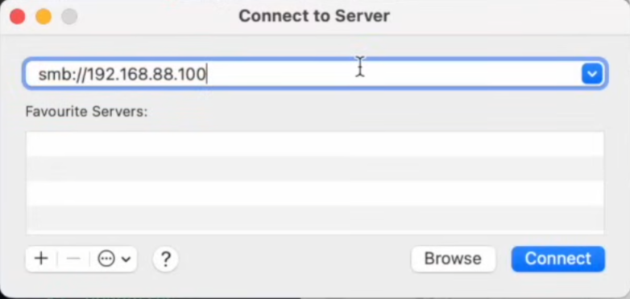

- `Windows` User, right click and select `Add a network location`

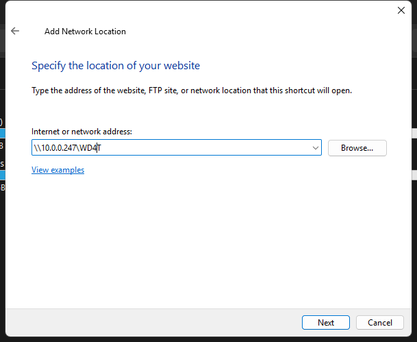

- Now you're ready to explore the Hard drive connected your laptop use LAN

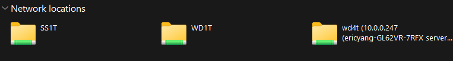

## Additional Tips: Prevent Laptop from Sleeping When Lid is Closed

### Method 1: Using the Graphical Interface

#### Open Power Settings:

1. Click on the system menu at the top right corner.
2. Select "Settings" and then go to "Power".

#### Adjust Lid Close Behavior:

1. Find the option "When the lid is closed" or similar.
2. Set it to "Do nothing" or "Turn off screen only". The exact options may vary depending on the version.

#### Save Settings:

1. Close the settings window.

### Method 2: Editing Configuration File

If the graphical interface does not have the relevant options, you can set it by editing the configuration file:

#### Open Terminal:

1. Press `Ctrl+Alt+T` to open the terminal.

#### Edit logind.conf File:

1. Enter the following command to open the configuration file:

   ```
   sudo nano /etc/systemd/logind.conf
   ```

2. Find and modify the following two lines: Ensure the following two lines exist and are uncommented (remove the `#` at the beginning), and modify them to:

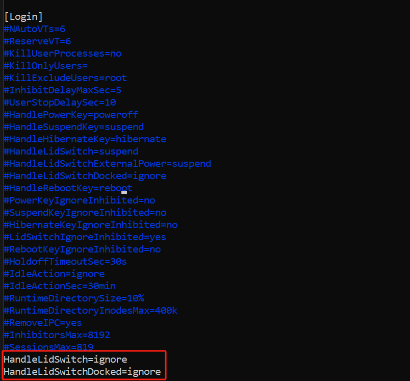

#### Save and Exit:

1. Press `Ctrl+O` to save.
2. Press `Ctrl+X` to exit the editor.

#### Restart systemd-logind Service:

1. To apply the changes, run the following command:

   ```
   sudo systemctl restart systemd-logind
   ```